# VGRecommendations_v1

## Video games recommendation system

The aim of this notebook is to create a recommendation system that will give the user products, similiar to the one they chose. This will be happening with the help of the Nearest neighbours model.

The iteration of the porject will be kept in a git repository

- git link - https://git.fhict.nl/I509460/video-game-reommendation.git

The project is created and work on by Mihail Kenarov

```python
import sklearn
import pandas as pd
import seaborn as sns
import matplotlib.pyplot as plt

print("scikit-learn version:", sklearn.__version__) # 1.4.1
print("pandas version:", pd.__version__)            # 2.2.1
print("seaborn version:", sns.__version__)          # 0.13.2
```

```
scikit-learn version: 1.4.1.post1
pandas version: 2.2.0
seaborn version: 0.13.2
```

# 📦 Data provisioning

### Data Requirment

We would need to find a suitable dataset that has some video games with data about them like genres,publishers etc.

## Data Collection

This data is availabe at the site of Kaggle. We will be using it as a csv file that has some information that does seem quite useful for us https://www.kaggle.com/datasets/asaniczka/video-game-sales-2024

```python
df = pd.read_csv('vgchartz-2024.csv')
df.head()
```

|  | img | title | console | genre | publisher | developer | critic_score | total_sales | na_sales | jp_sales | pal_sales | other_sales | release_date | last_update |
| --- | --- | --- | --- | --- | --- | --- | --- | --- | --- | --- | --- | --- | --- | --- |
| 0 | /games/boxart/full_6510540AmericaFrontccc.jpg | Grand Theft Auto V | PS3 | Action | Rockstar Games | Rockstar North | 9.4 | 20.32 | 6.37 | 0.99 | 9.85 | 3.12 | 2013-09-17 | NaN |
| 1 | /games/boxart/full_5563178AmericaFrontccc.jpg | Grand Theft Auto V | PS4 | Action | Rockstar Games | Rockstar North | 9.7 | 19.39 | 6.06 | 0.60 | 9.71 | 3.02 | 2014-11-18 | 2018-01-03 |
| 2 | /games/boxart/827563ccc.jpg | Grand Theft Auto: Vice City | PS2 | Action | Rockstar Games | Rockstar North | 9.6 | 16.15 | 8.41 | 0.47 | 5.49 | 1.78 | 2002-10-28 | NaN |
| 3 | /games/boxart/full_9218923AmericaFrontccc.jpg | Grand Theft Auto V | X360 | Action | Rockstar Games | Rockstar North | NaN | 15.86 | 9.06 | 0.06 | 5.33 | 1.42 | 2013-09-17 | NaN |
| 4 | /games/boxart/full_4990510AmericaFrontccc.jpg | Call of Duty: Black Ops 3 | PS4 | Shooter | Activision | Treyarch | 8.1 | 15.09 | 6.18 | 0.41 | 6.05 | 2.44 | 2015-11-06 | 2018-01-14 |

We see that we do have a lot of data to work with however I do not believe that some of the columns are needed that much when It comes to finding the most suitable game for the one that a user has chosen in this Jypyter notebook. I would say that `last_update`, `img`, `pal_sales`, `other_sales` are currently unnecesary so I will drop them

```python
columns_to_drop = ['last_update', 'img', 'pal_sales', 'other_sales']
cleaned_df = df.drop(columns_to_drop, axis=1)
cleaned_df.head(10)
```

|  | title | console | genre | publisher | developer | critic_score | total_sales | na_sales | jp_sales | release_date |
| --- | --- | --- | --- | --- | --- | --- | --- | --- | --- | --- |
| 0 | Grand Theft Auto V | PS3 | Action | Rockstar Games | Rockstar North | 9.4 | 20.32 | 6.37 | 0.99 | 2013-09-17 |
| 1 | Grand Theft Auto V | PS4 | Action | Rockstar Games | Rockstar North | 9.7 | 19.39 | 6.06 | 0.60 | 2014-11-18 |
| 2 | Grand Theft Auto: Vice City | PS2 | Action | Rockstar Games | Rockstar North | 9.6 | 16.15 | 8.41 | 0.47 | 2002-10-28 |
| 3 | Grand Theft Auto V | X360 | Action | Rockstar Games | Rockstar North | NaN | 15.86 | 9.06 | 0.06 | 2013-09-17 |
| 4 | Call of Duty: Black Ops 3 | PS4 | Shooter | Activision | Treyarch | 8.1 | 15.09 | 6.18 | 0.41 | 2015-11-06 |
| 5 | Call of Duty: Modern Warfare 3 | X360 | Shooter | Activision | Infinity Ward | 8.7 | 14.82 | 9.07 | 0.13 | 2011-11-08 |
| 6 | Call of Duty: Black Ops | X360 | Shooter | Activision | Treyarch | 8.8 | 14.74 | 9.76 | 0.11 | 2010-11-09 |
| 7 | Red Dead Redemption 2 | PS4 | Action-Adventure | Rockstar Games | Rockstar Games | 9.8 | 13.94 | 5.26 | 0.21 | 2018-10-26 |
| 8 | Call of Duty: Black Ops II | X360 | Shooter | Activision | Treyarch | 8.4 | 13.86 | 8.27 | 0.07 | 2012-11-13 |
| 9 | Call of Duty: Black Ops II | PS3 | Shooter | Activision | Treyarch | 8.0 | 13.80 | 4.99 | 0.65 | 2012-11-13 |

## Current thoughts

Currenly I am not completly sure if all of these columns are things that are going to matter a lot to our system,but I will still go along with them for now. Let us create a dictionary with what we have

## Data Dictionary

As a first attempt to improve the data requirements, I have tried to add units and ranges to the data definition. It can also help to check the consistency and validity of the data.

(0) Title: The name of the game

(1) Console: The console on which the game is played on

(2) Genre: The genre of a game

(3) Publisher: The game publishers which could be considered 'The big names' of the industry

(4) Developer: The studio that worked on the creation of the game

(5) Critic score: The score that is given to a game from a certain agency (like IGN)

(6) Total sales: The number of times the game has been sold worldwide

(7) NA sales: The number of times a game has been sold in North America

(8) Japan sales: The number of times a game has been sold in Japan

## Genre Dictionary

Action - 1

Shooter - 2

Action-Adventure - 3

Sports - 4

Role-Playing - 5

Simulation - 6

Racing - 7

Music - 8

Misc - 9

Fighting - 10

Platform - 11

Adventure - 12

Strategy - 13

Puzzle - 14

MMO - 15

Sandbox - 16

Party - 17

Education - 18

Board Game - 19

Visual Novel - 20

### For now the data seems alright but let's check if there are some empty spaces, what kind of data are we working with and some general values in the dataset

```python
cleaned_df.info() # to see the type of data we are working with
```

```
<class 'pandas.core.frame.DataFrame'>
RangeIndex: 64016 entries, 0 to 64015
Data columns (total 10 columns):
 #   Column        Non-Null Count  Dtype
---  ------        --------------  -----
 0   title         64016 non-null  object
 1   console       64016 non-null  object
 2   genre         64016 non-null  object
 3   publisher     64016 non-null  object
 4   developer     63999 non-null  object
 5   critic_score  6678 non-null   float64
 6   total_sales   18922 non-null  float64
 7   na_sales      12637 non-null  float64
 8   jp_sales      6726 non-null   float64
 9   release_date  56965 non-null  object
dtypes: float64(4), object(6)
memory usage: 4.9+ MB
```

```python
print(cleaned_df.isna().sum()) # to see the missing values
```

```
title               0
console             0
genre               0
publisher           0
developer          17
critic_score    57338
total_sales     45094
na_sales        51379
jp_sales        57290
release_date     7051
dtype: int64
```

```python
print(cleaned_df.describe()) # to get a bit of general knowledge about the data in the dataset currently
```

```
       critic_score   total_sales      na_sales     jp_sales
count   6678.000000  18922.000000  12637.000000  6726.000000
mean       7.220440      0.349113      0.264740     0.102281
std        1.457066      0.807462      0.494787     0.168811
min        1.000000      0.000000      0.000000     0.000000
25%        6.400000      0.030000      0.050000     0.020000
50%        7.500000      0.120000      0.120000     0.040000
75%        8.300000      0.340000      0.280000     0.120000
max       10.000000     20.320000      9.760000     2.130000
```

### Current thoughts

There is quite a lot of missing data still that I am not sure I cmopletly need. After more research I will come to a better conclusion.

## What we currently know

(5) Critic score: The maximum score is 10 and the minimum is 1(out of 10)

(6) Total sales: The maximum amount of sales of a game is 20.32 million while the minimum found was 0 on a worldwide scale

(7) NA sales: The maximum amount of sales of a game is 9.76 million while the minimum found was 0 on a NA scale

(8) Japan sales: The maximum amount of sales of a game is 2.13 million while the minimum found was 0 on a Japan scale

### As we are about to create a video games recommendation system it would be a good idea to have some insight on the genres

```python
unique_genres = cleaned_df['genre'].nunique()
print(f"Number of unique genres: {unique_genres}")
cleaned_df['genre'].unique()
```

```
Number of unique genres: 20
```

```
array(['Action', 'Shooter', 'Action-Adventure', 'Sports', 'Role-Playing',
       'Simulation', 'Racing', 'Music', 'Misc', 'Fighting', 'Platform',
       'Adventure', 'Strategy', 'Puzzle', 'MMO', 'Sandbox', 'Party',
       'Education', 'Board Game', 'Visual Novel'], dtype=object)
```

### Let's see if we could possibly use the publishers for the creation of our recommendation system

```python
unique_genres = cleaned_df['publisher'].nunique()
print(f"Number of unique publishers: {unique_genres}")
cleaned_df['publisher'].unique()
```

```
Number of unique publishers: 3383
```

```
array(['Rockstar Games', 'Activision', 'EA Sports', ...,
       "Mind's Eclipse Interactive", 'Walkabout', 'InvertMouse'],
      dtype=object)
```

### Let's also have a look at the amount of games from a specific publisher

```python
publisher_counts = cleaned_df['publisher'].value_counts()
print(publisher_counts)
```

```
publisher
Unknown               8842
Sega                  2207
Ubisoft               1663
Electronic Arts       1619
Activision            1582
                      ...
Cancer Research UK       1
XperimentalZ Games       1
Nano Games               1
Cooking Mama Ltd.        1
PLAYDIUS                 1
Name: count, Length: 3383, dtype: int64
```

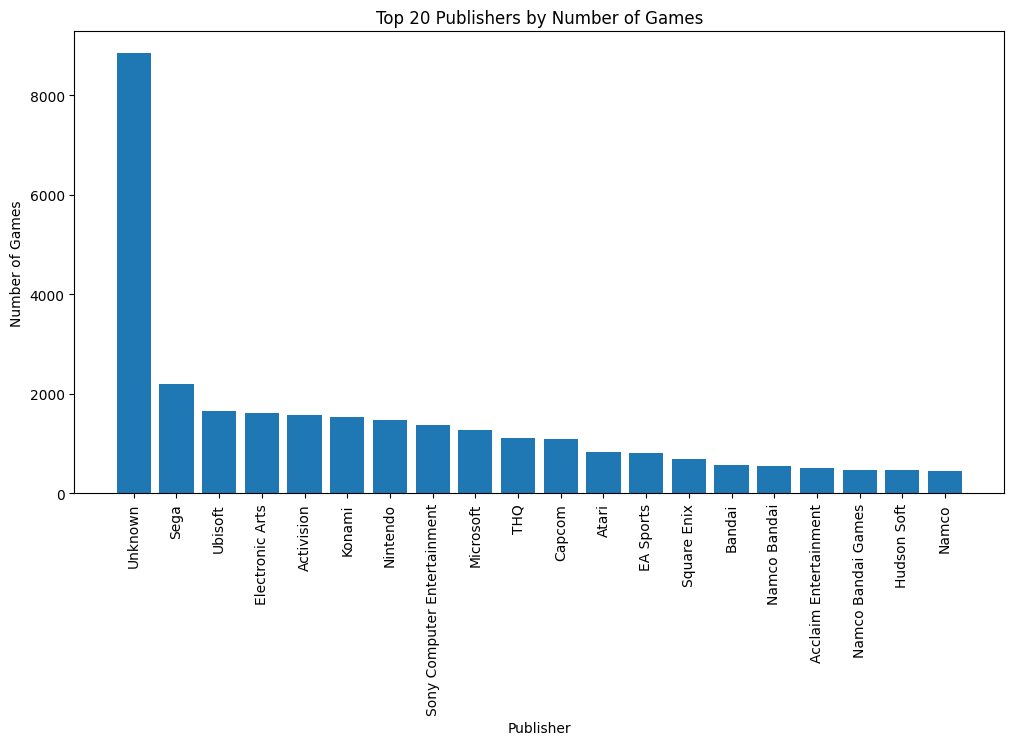

```python
# Let's visualize the results for a better understanding
publisher_counts = cleaned_df['publisher'].value_counts()

# Select the top 20 publishers
top_20_publishers = publisher_counts[:20]

# Create a bar chart for the top 20 publishers
plt.figure(figsize=(12, 6)) # Adjust the size of the figure
plt.bar(top_20_publishers.index, top_20_publishers.values)
plt.xlabel('Publisher')
plt.ylabel('Number of Games')
plt.title('Top 20 Publishers by Number of Games')
plt.xticks(rotation=90) # Rotate x-axis labels for better readability
plt.show()
```

### It does not look very promising to try and calculate things based of the publishers

## We are also going to be using the critic scores so it might be a good idea to see the range and distribution of the critic scores seperatly

```python
critic_score_range = cleaned_df['critic_score'].describe()
print(critic_score_range)
```

```
count    6678.000000
mean        7.220440
std         1.457066
min         1.000000
25%         6.400000
50%         7.500000
75%         8.300000
max        10.000000
Name: critic_score, dtype: float64
```

```python
cleaned_df.sample(25)
```

|  | title | console | genre | publisher | developer | critic_score | total_sales | na_sales | jp_sales | release_date |
| --- | --- | --- | --- | --- | --- | --- | --- | --- | --- | --- |
| 3148 | Ty the Tasmanian Tiger 2: Bush Rescue | PS2 | Platform | Electronic Arts | Krome Studios | 7.3 | 0.53 | 0.26 | NaN | 2004-10-12 |
| 14338 | Hyakumanton no Bara Bara | PSP | Strategy | Sony Computer Entertainment | Acquire | NaN | 0.03 | NaN | 0.03 | 2010-02-18 |
| 27103 | Shinkyoku Soukai Polyphonica: After School | PS2 | Adventure | Prototype | Visual Arts | NaN | NaN | NaN | NaN | 2010-11-11 |
| 63391 | Eternal Card Game | XOne | Strategy | Unknown | Dire Wolf Digital | NaN | NaN | NaN | NaN | NaN |
| 11441 | Rec Room Games | DS | Misc | Destineer | Destineer | NaN | 0.07 | 0.07 | NaN | 2011-02-11 |
| 38993 | What's the Word? | And | Misc | Red-Spell | Unknown | NaN | NaN | NaN | NaN | 2012-11-07 |
| 135 | Teenage Mutant Ninja Turtles | NES | Platform | Ultra Games | Konami | 5.9 | 4.17 | 3.38 | 0.31 | 1989-06-01 |
| 40160 | Shantae and the Pirate's Curse | PC | Platform | WayForward | WayForward | NaN | NaN | NaN | NaN | 2015-04-23 |
| 56437 | Daiva Story 6: Imperial of Nirsartia | NES | Simulation | Toshiba EMI | Tikipod | NaN | NaN | NaN | NaN | 1986-12-05 |
| 41795 | Super Adventure Island II | SNES | Platform | Hudson Soft | Hudson Soft | NaN | NaN | NaN | NaN | 1994-10-01 |
| 38359 | The Banner Saga | PC | Misc | Versus Evil | Unknown | NaN | NaN | NaN | NaN | 2014-01-14 |
| 2257 | WWF Attitude | N64 | Fighting | Acclaim Entertainment | Iguana Entertainment | NaN | 0.71 | 0.57 | NaN | 1999-07-31 |
| 47278 | art of rally | PC | Racing | Funselektor Labs Inc. | Funselektor Labs Inc. | NaN | NaN | NaN | NaN | 2020-09-23 |
| 23025 | Ultraman 2: Shutsugeki Katoku Tai!! (FDS) | NES | Action | Bandai | Tsuburaya Prod. | NaN | NaN | NaN | NaN | 1987-12-18 |
| 4467 | Virtua Fighter 3tb | DC | Fighting | Sega | Sega | 8.1 | 0.37 | NaN | 0.37 | 1999-10-18 |
| 48936 | Dragon Age Origins: Darkspawn Chronicles | PSN | Role-Playing | Electronic Arts | BioWare Corp. | 5.0 | NaN | NaN | NaN | 2010-05-18 |
| 45239 | ATONE: Heart of the Elder Tree | PC | Puzzle | Unknown | Wildboy Studios | NaN | NaN | NaN | NaN | NaN |
| 663 | Toy Story 2: Buzz Lightyear to the Rescue! | PS | Platform | Activision | Traveller's Tales | NaN | 1.71 | 0.99 | NaN | 1999-11-30 |
| 25112 | Alice no Yakata 7 | PC | Adventure | Alice Soft | Alice Soft | NaN | NaN | NaN | NaN | 2004-12-17 |
| 50256 | Space Rangers 2: Reboot | PC | Role-Playing | eGames | Elemental Games | NaN | NaN | NaN | NaN | 2009-02-26 |
| 38143 | Super Double Yakuman | SNES | Misc | Vap | Vap | NaN | NaN | NaN | NaN | 1994-04-01 |
| 41464 | Pucca's Kisses Game | WW | Platform | Big Ben Interactive | Bigben Interactive | NaN | NaN | NaN | NaN | 2011-02-14 |
| 30765 | Naruto Shippuden: Ultimate Ninja Storm 4 | XOne | Fighting | Namco Bandai Games | CyberConnect2 | NaN | NaN | NaN | NaN | 2016-02-09 |
| 24385 | Streets of Red: Devil's Dare Deluxe | PS4 | Action | Unknown | Secret Base | NaN | NaN | NaN | NaN | NaN |
| 46555 | Moto Racer | PC | Racing | Electronic Arts | Delphine Software International | NaN | NaN | NaN | NaN | 1997-08-31 |

```python
cleaned_df.shape
```

```
(64016, 10)
```

### I am beggining to question if dropping the rows where the critic scores is missing would be a good idea, but I am still not 100% sure, maybe some kind of imputation might work, but still it is hard to do so, since there are action games for example that get a higher or lower rating

```
higher rating - 7.3	-Elebits
lower rating - 3.0	-Prison Break: The Conspiracy
```

## Let's consider the idea of that each game is connected to only one genre, this way we can label the genres with a specific number so that it might be easier for the model to differentiate which game is which!

### (A dictionary was added beforehand for easier understanding)

```python
genre_mapping = {
    'Action': 1,
    'Shooter': 2,
    'Action-Adventure': 3,
    'Sports': 4,
    'Role-Playing': 5,
    'Simulation': 6,
    'Racing': 7,
    'Music': 8,
    'Misc': 9,
    'Fighting': 10,
    'Platform': 11,
    'Adventure': 12,
    'Strategy': 13,
    'Puzzle': 14,
    'MMO': 15,
    'Sandbox': 16,
    'Party': 17,
    'Education': 18,
    'Board Game': 19,
    'Visual Novel': 20
}


# Applying the mapping to the genre column and store the result in a new column 'genred_lbl'
cleaned_df['genred_lbl'] = cleaned_df['genre'].map(genre_mapping)


# verifying the transformation
print(cleaned_df[['genre', 'genred_lbl']].sample(15))
```

```
              genre  genred_lbl
427            Misc           9
17282        Sports           4
55146       Shooter           2
8538        Shooter           2
10637        Sports           4
51139  Role-Playing           5
28489     Adventure          12
37013          Misc           9
16476      Strategy          13
17561  Visual Novel          20
5939     Simulation           6
24136        Action           1
42328      Platform          11
37410          Misc           9
35817          Misc           9
```

## Now let's see what we have done with the changes

```python
cleaned_df.sample(15)
```

|  | title | console | genre | publisher | developer | critic_score | total_sales | na_sales | jp_sales | release_date | genred_lbl |
| --- | --- | --- | --- | --- | --- | --- | --- | --- | --- | --- | --- |
| 19114 | Star Wars: Episode III – Revenge of the Sith | All | Action | LucasArts | The Collective | NaN | NaN | NaN | NaN | 2005-05-04 | 1 |
| 16820 | Doki-Doki Universe | PSV | Misc | Sony Computer Entertainment | HumaNature Studios | NaN | 0.01 | 0.00 | NaN | 2013-12-10 | 9 |
| 41101 | Lilly Adventure | 2600 | Platform | Unknown | Quelle | NaN | NaN | NaN | NaN | 1983-01-01 | 11 |
| 43702 | Flash Koibito-Kun | WS | Puzzle | Koubunsha | Koto | NaN | NaN | NaN | NaN | 2000-12-28 | 14 |
| 30692 | Street Fighter II | All | Fighting | Capcom | Capcom | NaN | NaN | NaN | NaN | 1991-02-15 | 10 |
| 236 | Assassin's Creed Odyssey | PS4 | Action-Adventure | Ubisoft | Ubisoft Quebec | 9.5 | 3.18 | 1.18 | 0.09 | 2018-10-05 | 3 |
| 37259 | Retroball 3000 | And | Misc | Unknown | Unknown | NaN | NaN | NaN | NaN | 2014-05-23 | 9 |
| 62745 | Sheep | PC | Strategy | Empire Interactive | Minds-Eye | NaN | NaN | NaN | NaN | 2000-11-29 | 13 |
| 13693 | BeatMania IIDX 16: Empress + Premium Best | PS2 | Simulation | Konami | Konami | NaN | 0.04 | NaN | 0.04 | 2009-10-15 | 6 |
| 61052 | Fallout Tactics | PC | Strategy | 14 Degrees East | Micro Forte | NaN | NaN | NaN | NaN | 2001-03-14 | 13 |
| 42422 | FOX n FORESTS | PS4 | Platform | Unknown | Bonus Level Entertainment | NaN | NaN | NaN | NaN | NaN | 11 |
| 52362 | 99Bullets | DSiW | Shooter | Unknown | EnjoyUp Games | NaN | NaN | NaN | NaN | 2011-05-23 | 2 |
| 32551 | Ace Combat: Infinity | PS3 | Misc | Namco Bandai Games | Unknown | NaN | NaN | NaN | NaN | 2020-12-31 | 9 |
| 49707 | Mass Effect 2: The Arrival | PSN | Role-Playing | Electronic Arts | BioWare Edmonton | 7.0 | NaN | NaN | NaN | 2011-03-28 | 5 |
| 47062 | Test Drive Le Mans | GB | Racing | Infogrames | Velez & Dubail | NaN | NaN | NaN | NaN | 2000-06-01 | 7 |